# 09 Benchmarking Within the Cryptocurrency Market

Kimberly Lin

2026-01-26

## 1. Motivation

**Bitcoin (BTC)** is used as an internal benchmark, representing the most liquid and dominant asset in the cryptocurrency market.

This section evaluates whether other major cryptocurrencies exhibit systematically higher risk relative to Bitcoin.

## 2. Benchmark Definition

- **Benchmark asset**: Bitcoin (BTC)
- **Comparison assets**: Ethereum (ETH), Binance (BNB)
- **Risk dimensions**:
  - Volatility
  - Drawdowns
  - Crash frequency
  - Tail behavior (from previous sections)

BTC serves as a market proxy due to its market dominance, liquidity, and longest trading history.

## 3. Volatility Benchmarking

What we show: - Table: σ(log returns) for BTC / ETH / BNB - Optional bar chart

ETH and BNB consistently exhibit higher return volatility relative to Bitcoin, indicating increased short-term risk exposure.

## 4. Drawdown Severity Comparison

What we show:

## 5. Crash Frequency Benchmark

What we show:

- Crash ratio table（≥10% daily loss）
- BTC vs others

Extreme single-day losses occur more frequently in non-BTC assets, highlighting the stabilizing role of market size and liquidity.

## 7. Why This Benchmarking Matters?

Internal benchmarking avoids inappropriate cross-asset comparisons and provides a more realistic assessment of relative risk within the cryptocurrency ecosystem.

```r
library(tidyverse)
library(lubridate)
library(here)

source(here("src/utils/return_calculations.R"))
```

```r
## Load processed data
btc <- read_csv(here("data/processed/BTC_clean.csv"))
eth <- read_csv(here("data/processed/ETH_clean.csv"))
bnb <- read_csv(here("data/processed/BNB_clean.csv"))

## Compute log returns
btc_ret <- calc_log_returns(btc)
eth_ret <- calc_log_returns(eth)
bnb_ret <- calc_log_returns(bnb)

## Compute drawdowns
btc_dd <- compute_drawdown(btc_ret)
eth_dd <- compute_drawdown(eth_ret)
bnb_dd <- compute_drawdown(bnb_ret)

## Crash detection
btc_crash <- detect_crash(btc_ret)
eth_crash <- detect_crash(eth_ret)
bnb_crash <- detect_crash(bnb_ret)
```

```r
risk_summary <- tibble(
  asset = c("BTC", "ETH", "BNB"),
  volatility = c(
    sd(btc_ret$log_return),
    sd(eth_ret$log_return),
    sd(bnb_ret$log_return)
  ),
  max_drawdown = c(
    min(btc_dd$drawdown),
    min(eth_dd$drawdown),
    min(bnb_dd$drawdown)
  ),
  crash_ratio = c(
    mean(btc_crash$crash),
    mean(eth_crash$crash),
    mean(bnb_crash$crash)
  )
)
risk_summary
```

```
## # A tibble: 3 × 4
##   asset volatility max_drawdown crash_ratio
##   <chr>      <dbl>        <dbl>       <dbl>
## 1 BTC       0.0482        -2.68      0.0210
## 2 ETH       0.0535        -2.81      0.0265
## 3 BNB       0.0575        -1.61      0.0227
```

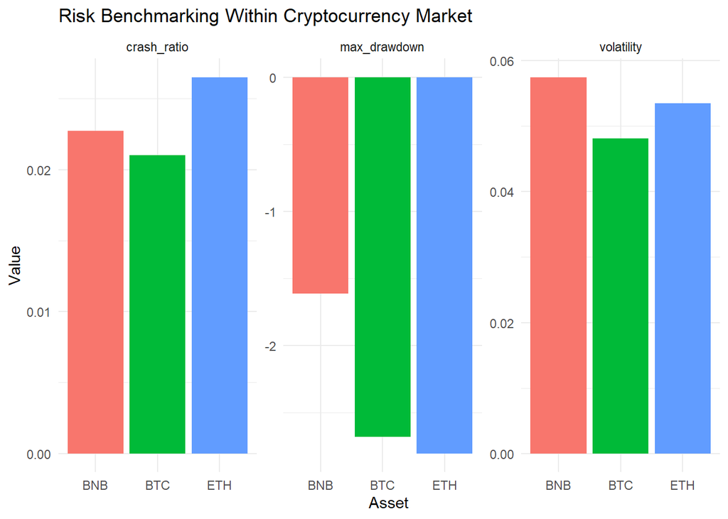

```r
risk_summary %>%
  pivot_longer(-asset) %>%
  ggplot(aes(x = asset, y = value, fill = asset)) +
  geom_col(show.legend = FALSE) +
  facet_wrap(~ name, scales = "free_y") +
  labs(
    title = "Risk Benchmarking Within Cryptocurrency Market",
    x = "Asset",
    y = "Value"
  ) +
  theme_minimal()
```